## Регрессионный анализ данных car2004

```r
library(memisc)
library(coefplot)
library(glmnet)
library(MASS)
library(QuantPsyc)
library(ellipse)
library(olsrr)
library(kableExtra)
library(zoo)
library(ppcor)
library(readr)
library(ggplot2)
library(hrbrthemes)
library(tidyverse)
library(readxl)
library(GGally)
library(psych)
library(plotly)
library(nortest)
library(summarytools)
library(scatterPlotMatrix)
library(viridis)
library(patchwork)
library(gridExtra)
library(ggpubr)
library(car)
library(e1071)
library(cowplot)
library(corrplot)
library(reshape2)

print_df <- function(df)
{
  df |>
    kable(format = "html") |>
    kable_styling() |>
    kableExtra::scroll_box(width = "100%", height = "100%")
}

create_ggpairs <- function(data, density_diag = TRUE, fig_width = 15, fig_height = 7) {
  if (density_diag) {
    ggpairs(data, diag = list(continuous = "densityDiag", discrete = "barDiag", na = "naDiag", mapping = aes(fill = "red")), fig.width = fig_width, fig.height = fig_height)
  } else {
    ggpairs(data, diag = list(continuous = "barDiag", mapping = aes(fill = "red")), fig.width = fig_width, fig.height = fig_height)
  }
}
```

## 1. Загрузка данных

```r
data <- read_excel("C:/Users/redmi/Documents/R analysis/car2004.xls", na = "*")
colnames(data) <- gsub("-", "_", colnames(data))

head(data, 5) |>
 print_df()
```

| Name | Sport | SportUtil | Wagon | Minivan | Pickup | All_wheel | Rear_wheel | Retail | Dealer | Engine | Cylinders | Horsepower | CityMPG | HW_MPG | Weight | WheelBase | Length | Width |
| --- | --- | --- | --- | --- | --- | --- | --- | --- | --- | --- | --- | --- | --- | --- | --- | --- | --- | --- |
| Chevrolet Aveo 4dr | 0 | 0 | 0 | 0 | 0 | 0 | 0 | 11690 | 10965 | 1.6 | 4 | 103 | 28 | 34 | 2370 | 98 | 167 | 66 |
| Chevrolet Aveo LS 4dr hatch | 0 | 0 | 0 | 0 | 0 | 0 | 0 | 12585 | 11802 | 1.6 | 4 | 103 | 28 | 34 | 2348 | 98 | 153 | 66 |
| Chevrolet Cavalier 2dr | 0 | 0 | 0 | 0 | 0 | 0 | 0 | 14610 | 13697 | 2.2 | 4 | 140 | 26 | 37 | 2617 | 104 | 183 | 69 |
| Chevrolet Cavalier 4dr | 0 | 0 | 0 | 0 | 0 | 0 | 0 | 14810 | 13884 | 2.2 | 4 | 140 | 26 | 37 | 2676 | 104 | 183 | 68 |
| Chevrolet Cavalier LS 2dr | 0 | 0 | 0 | 0 | 0 | 0 | 0 | 16385 | 15357 | 2.2 | 4 | 140 | 26 | 37 | 2617 | 104 | 183 | 69 |

## 2. Описание признаков

Частота мод

```r
modes<-summarize(data, across(Name:Width, function(x) max(table(x))))
print_df(modes)
```

| Name | Sport | SportUtil | Wagon | Minivan | Pickup | All_wheel | Rear_wheel | Retail | Dealer | Engine | Cylinders | Horsepower | CityMPG | HW_MPG | Weight | WheelBase | Length | Width |
| --- | --- | --- | --- | --- | --- | --- | --- | --- | --- | --- | --- | --- | --- | --- | --- | --- | --- | --- |
| 2 | 379 | 368 | 398 | 408 | 404 | 336 | 318 | 2 | 2 | 42 | 190 | 17 | 68 | 54 | 4 | 45 | 26 | 55 |

Количество уникальных значений по каждому признаку

```r
unique_counts <- sapply(data, function(x) n_distinct(x, na.rm = TRUE))
print(unique_counts)
```

```
##       Name      Sport  SportUtil      Wagon    Minivan     Pickup  All_wheel
##        425          2          2          2          2          2          2
## Rear_wheel     Retail     Dealer     Engine  Cylinders Horsepower    CityMPG
##          2        410        425         43          8        110         28
##     HW_MPG     Weight  WheelBase     Length      Width
##         32        347         39         61         18
```

*Комментарий.* Несмотря на то, что у Horsepower довольно большая частота мод, но уникальных значений примерно 25% от всего объема данных, поэтому я посчитала, что логичнее будет считать этот признак непрерывным.

В городском цикле обычно встречаются частые остановки, старты и пробки, что приводит к более частому использованию тормозов и ускорителей. Это может уменьшить экономию топлива.

В условиях шоссейного движения меньше остановок и меньше стартов, что может способствовать более высокой экономии топлива.

То есть ожидается, что HW_MPG > CityMPG.

*Комментарий.* Почему-то здесь считается, что “Sport” – это тоже тип кузова. Предположим, что это означает типы кузовов, наиболее характерные для спортивных автомобилей, например, Roadster. Тогда к Other (6 тип кузова) мы отнесем Coupe, Sedan и Hatchback.

*Две группы качаственных признаков – тип кузова и тип привода уже представленны в виде dummy variables (при этом не учтены “другой” тип кузова и передний привод, поэтому никакие признаки убирать не нужно), поэтому никаких дополнительных манипуляций с данными производить не нужно.*

## 3. Симметричность

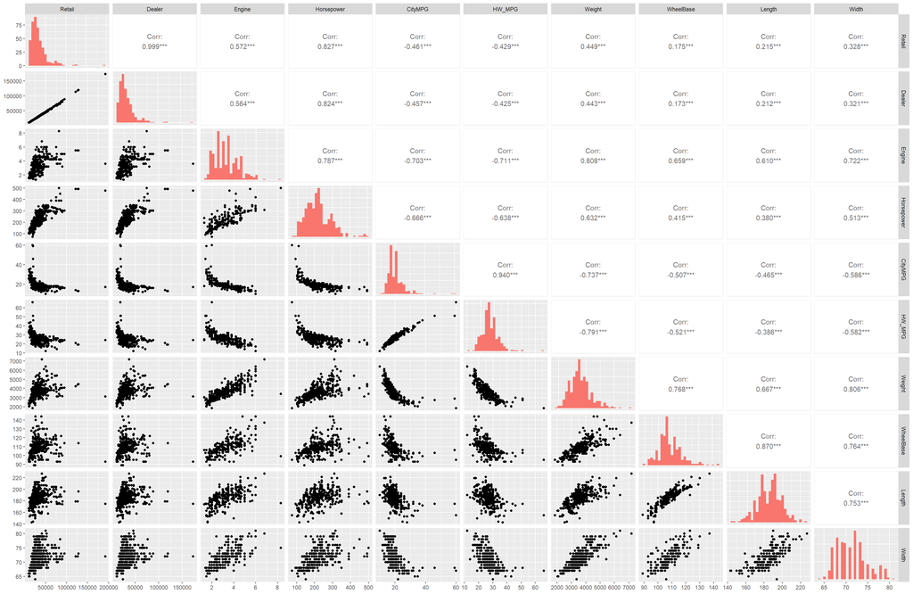

```r
data_select <- data %>% select(-Name, -Sport, -SportUtil,-Wagon, -Minivan, -Pickup, -All_wheel, -Rear_wheel, -Cylinders)

create_ggpairs(data_select, density_diag = FALSE)
```

Наблюдения Retail,Dealer,Engine,Horsepower,CityMPG,HW_MPG, Weight, WheelBase имеют хвост вправо, прологарифмируем их и построим графики зависимостей признаков.

## 4. Графики зависимостей признаков

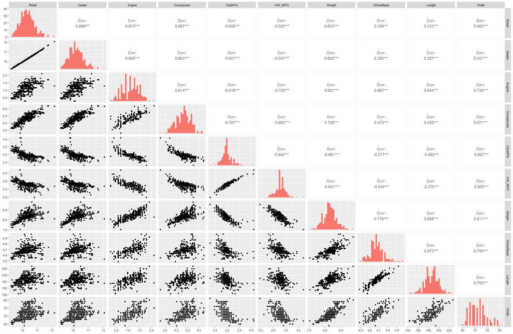

```r
data_log <- data %>%
  mutate_at(vars(Retail, Dealer, Engine, Horsepower, CityMPG, HW_MPG, Weight, WheelBase), ~log(.))

data_select <- data_log %>% select(-Name, -Sport, -SportUtil,-Wagon, -Minivan, -Pickup, -All_wheel, -Rear_wheel, -Cylinders)

create_ggpairs(data_select, density_diag = FALSE)
```

## 5. Заполнение пропусков

Количество пропущенных значений для каждого признака

```r
na_count <- colSums(is.na(data_log))
print(na_count)
```

```
##       Name      Sport  SportUtil      Wagon    Minivan     Pickup  All_wheel
##          0          0          0          0          0          0          0
## Rear_wheel     Retail     Dealer     Engine  Cylinders Horsepower    CityMPG
##          0          0          0          0          0          0         14
##     HW_MPG     Weight  WheelBase     Length      Width
##         14          2         18         26         28
```

Так как пропусков не так много, то заполним их медианным значением по каждому признаку.

```r
cols_to_fill <- c("CityMPG", "HW_MPG", "Weight", "WheelBase", "Length", "Width")
filled_cols <- na.aggregate(data_log[, cols_to_fill], FUN = median, na.rm = TRUE)
data_log[, cols_to_fill] <- filled_cols
```

# 6. Корреляция между признаками

На основе предыдущего графика, все корреляции значимы.

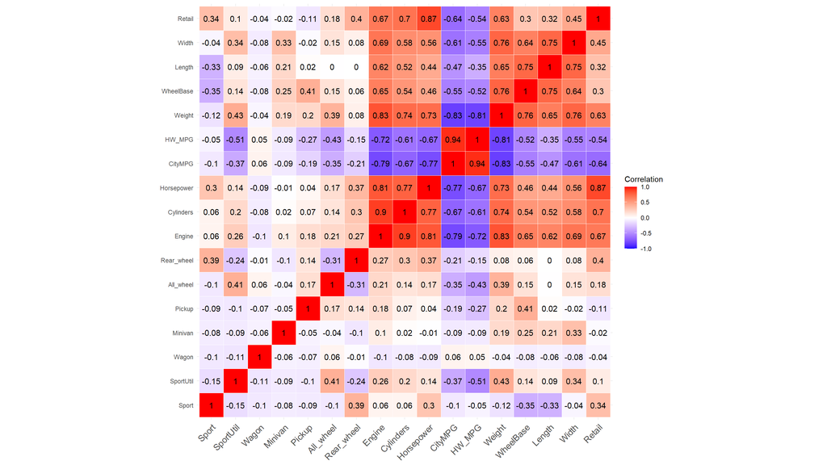

```r
data_reg <- data_log[, c(names(data_log)[!names(data_log) %in% c("Name", "Dealer", "Retail")], "Retail")]

correlation_matrix <- cor(data_reg)

correlation_data <- melt(correlation_matrix)

options(repr.plot.width=14, repr.plot.height=8)

ggplot(data = correlation_data, aes(x = Var1, y = Var2, fill = value, label = round(value, 2))) +
  geom_tile(color = "white") +
  geom_text(color = "black", size = 4, hjust = 0.5, vjust = 0.5) +
  scale_fill_gradient2(low = "blue", high = "red", mid = "white",
                       midpoint = 0, limit = c(-1,1), space = "Lab",
                       name="Correlation") +
  theme_minimal() +
  theme(axis.text.x = element_text(angle = 45, vjust = 1, size = 12, hjust = 1),
        axis.title = element_blank()) +
  coord_fixed()
```

Так как CityMPG и HW_MPG сильно коррелируют (корреляция равна 0,94), то уберем один из признаков. Так как корреляция CityMPG и Retail больше, то оставим его.

Cylinders и Engine тоже сильно коррелируют (корреляция равна 0,9), так как корреляция Cylinders и Retail больше, то оставим его.

Также уберем Weight.

*Убедимся, что эти переменные стоит убрать, посмотрев на полную модель*

```r
model_0 <- lm(Retail ~ Sport + SportUtil +  Wagon + Minivan + Pickup +  All_wheel +  Rear_wheel +                                     Engine + Cylinders + Horsepower +  CityMPG + HW_MPG +  Weight + WheelBase +
                       Length  +  Width, data = data_log)
summary(model_0)
```

```
##
## Call:
## lm(formula = Retail ~ Sport + SportUtil + Wagon + Minivan + Pickup +
##     All_wheel + Rear_wheel + Engine + Cylinders + Horsepower +
##     CityMPG + HW_MPG + Weight + WheelBase + Length + Width, data = data_log)
##
## Residuals:
##     Min      1Q  Median      3Q     Max
## -0.5342 -0.1133 -0.0153  0.1071  0.9945
##
## Coefficients:
##               Estimate Std. Error t value Pr(>|t|)
## (Intercept) -0.3692312  1.4022385  -0.263 0.792439
## Sport        0.1138221  0.0455832   2.497 0.012915 *
## SportUtil   -0.1385315  0.0483961  -2.862 0.004419 **
## Wagon       -0.0376159  0.0398076  -0.945 0.345243
## Minivan     -0.0410891  0.0576879  -0.712 0.476705
## Pickup      -0.3441138  0.0644789  -5.337 1.57e-07 ***
## All_wheel    0.0983371  0.0314174   3.130 0.001873 **
## Rear_wheel   0.1766959  0.0292166   6.048 3.30e-09 ***
## Engine      -0.3103955  0.0912829  -3.400 0.000739 ***
## Cylinders    0.0562729  0.0150666   3.735 0.000214 ***
## Horsepower   0.9206064  0.0711332  12.942  < 2e-16 ***
## CityMPG     -0.0431276  0.1861009  -0.232 0.816853
## HW_MPG       0.3344930  0.2027829   1.650 0.099807 .
## Weight       1.3596708  0.1563732   8.695  < 2e-16 ***
## WheelBase   -1.1219336  0.3122104  -3.594 0.000366 ***
## Length      -0.0003477  0.0017810  -0.195 0.845323
## Width       -0.0143477  0.0063241  -2.269 0.023802 *
## ---
## Signif. codes:  0 '***' 0.001 '**' 0.01 '*' 0.05 '.' 0.1 ' ' 1
##
## Residual standard error: 0.1987 on 411 degrees of freedom
## Multiple R-squared:  0.8396, Adjusted R-squared:  0.8333
## F-statistic: 134.4 on 16 and 411 DF,  p-value: < 2.2e-16
```

```r
ols_vif_tol(model_0)
```

```
##     Variables  Tolerance       VIF
## 1       Sport 0.43781238  2.284083
## 2   SportUtil 0.32667406  3.061155
## 3       Wagon 0.89289023  1.119958
## 4     Minivan 0.62211904  1.607409
## 5      Pickup 0.41908933  2.386126
## 6   All_wheel 0.55369010  1.806064
## 7  Rear_wheel 0.56578785  1.767447
## 8      Engine 0.09167211 10.908443
## 9   Cylinders 0.15463688  6.466763
## 10 Horsepower 0.16915837  5.911620
## 11    CityMPG 0.05674020 17.624188
## 12     HW_MPG 0.05557617 17.993325
## 13     Weight 0.08903103 11.232038
## 14  WheelBase 0.17454968  5.729028
## 15     Length 0.17505663  5.712437
## 16      Width 0.21469429  4.657786
```

VIF показывает насколько увеличивается дисперсия оценок коэффициентов из-за мультиколлинеарности.

Посмотрев на модель со всеми переменными, можем убедиться, что эти переменные стоит убрать, так как значение VIF для них велико (больше 10).

**Почему стоит избавляться от мультиколлинеарности**

В случае наличия мультиколлинеарности матрица регрессоров имеет не полный ранг, а значит имеющиеся наблюдения не позволяют получить оценки МНК однозначно. Мультиколлинеарность также затрудняет интерпретацию коэффициентов регрессии.

## Модель

```r
data_log <- data_log %>%
  mutate_at(vars(-Name), scale)
```

```r
model <- lm(Retail ~ Sport + SportUtil +  Wagon + Minivan + Pickup +  All_wheel +  Rear_wheel +
                     Cylinders + Horsepower +  CityMPG +  WheelBase +
                     Length  +  Width, data = data_log)
summary(model)
```

```
##
## Call:
## lm(formula = Retail ~ Sport + SportUtil + Wagon + Minivan + Pickup +
##     All_wheel + Rear_wheel + Cylinders + Horsepower + CityMPG +
##     WheelBase + Length + Width, data = data_log)
##
## Residuals:
##      Min       1Q   Median       3Q      Max
## -1.30023 -0.28868 -0.05187  0.25992  1.66185
##
## Coefficients:
##               Estimate Std. Error t value Pr(>|t|)
## (Intercept) -1.585e-15  2.163e-02   0.000 1.000000
## Sport        3.602e-02  3.234e-02   1.113 0.266150
## SportUtil   -5.205e-02  3.110e-02  -1.674 0.094959 .
## Wagon        4.651e-03  2.256e-02   0.206 0.836770
## Minivan      3.574e-03  2.645e-02   0.135 0.892563
## Pickup      -1.826e-01  3.058e-02  -5.971 5.09e-09 ***
## All_wheel    1.426e-01  2.794e-02   5.104 5.08e-07 ***
## Rear_wheel   1.407e-01  2.865e-02   4.911 1.31e-06 ***
## Cylinders    1.398e-01  3.763e-02   3.715 0.000231 ***
## Horsepower   7.190e-01  4.831e-02  14.883  < 2e-16 ***
## CityMPG      6.577e-03  4.271e-02   0.154 0.877703
## WheelBase   -1.901e-02  4.800e-02  -0.396 0.692334
## Length      -1.339e-02  4.930e-02  -0.272 0.786008
## Width       -2.233e-02  4.541e-02  -0.492 0.623219
## ---
## Signif. codes:  0 '***' 0.001 '**' 0.01 '*' 0.05 '.' 0.1 ' ' 1
##
## Residual standard error: 0.4474 on 414 degrees of freedom
## Multiple R-squared:  0.8059, Adjusted R-squared:  0.7998
## F-statistic: 132.3 on 13 and 414 DF,  p-value: < 2.2e-16
```

```r
print(paste("AIC:", AIC(model)))
```

```
## [1] "AIC: 541.878715823123"
```

Среди значимых коэффициентов наибольший вклад вносит Horsepower, а наименьший (по модулю) – Cylinders. Модель значима: так как значение p-value очень мало, то нулевая гипотеза о незначимости регрессии отвергается. Значения $R^2$ и $R^2_{adjusted}$ довольно велики, значит, модель хорошо соответствует данным.

*Корреляции между оценками коэффициентов*

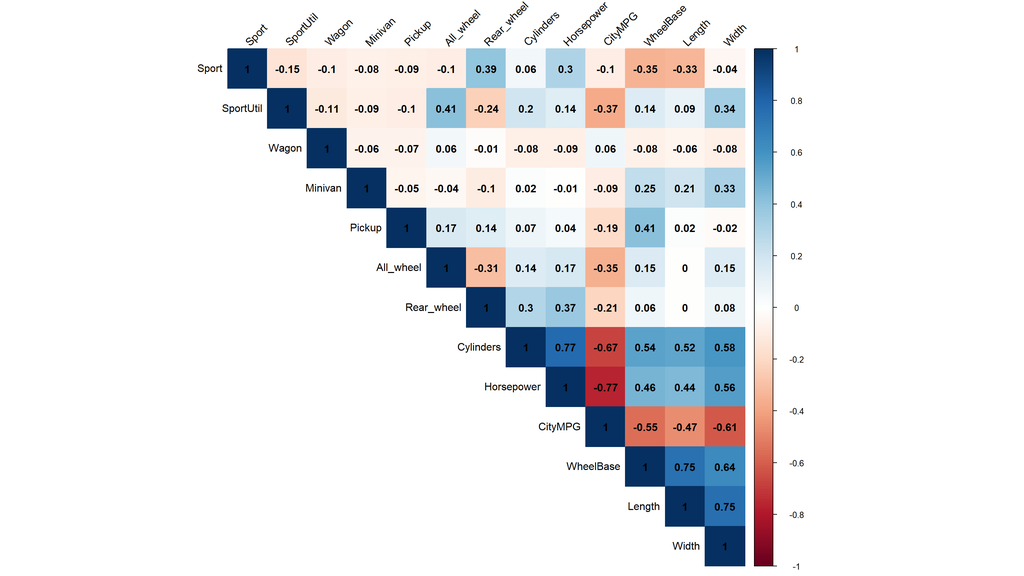

```r
model_matrix <- model.matrix(model)[,-1]
corr_matrix <- cor(model_matrix)

corrplot(corr_matrix,
         method = "color",
         type = "upper",
         tl.col = "black",
         tl.srt = 45,
         addCoef.col = "black")
```

Из графика видно, что корреляции между Horsepower и CityMPG, Cylinders и CityMPG, Width и CityMPG, WheelBase, Length, Width довольно велики, так что в дальнeйшем имеет смысл убрать из модели какие-то из этих признаков.

*Доверительный эллипсоид*

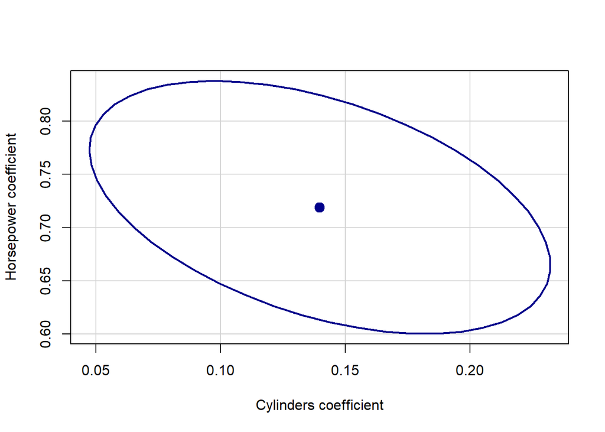

```r
which.coef <- c("Cylinders", "Horsepower")
confidenceEllipse(model, which.coef = which.coef, levels = 0.95, col = c("darkblue"))
```

В данном случае коэффициенты значимы в совокупности (даже если один близок к 0, то второй вполне далек и наоборот).

*Доверительные интервалы*

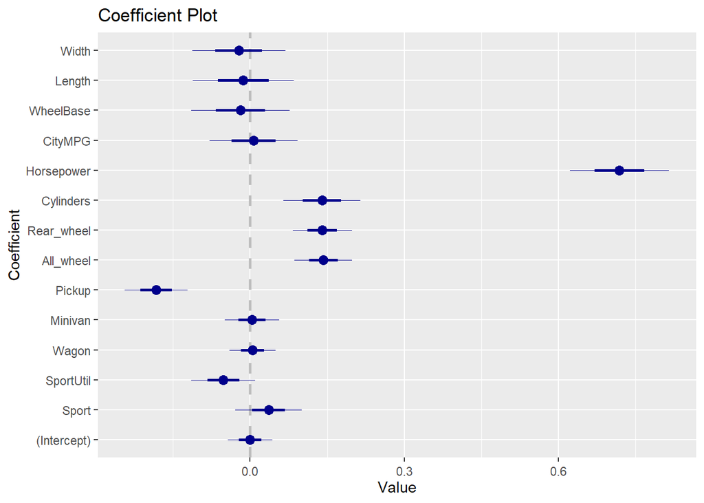

```r
coefplot(model, col = c("darkblue"))
```

Если доверительные интервалы не включают 0, это указывает, что коэффициенты статистически значимы. В данном случае это выполнено для Horsepower, Cylinders, Rear_wheel, All_wheel, Pickup, также можно учесть SportUtil и Sport.

## Выбор оптимальной модели: VIF, частные корреляции, stepwise forward и backward

*Посмотрим на значения VIF*

VIF для всех коэффициентов, кроме Length, меньше 5, так что можно считать, что мультиколлинеарности нет (так как для Length VIF совсем немного превышает 5, то будем считать, что эту переменную пока не стоит убирать).

```r
ols_vif_tol(model)
```

```
##     Variables Tolerance      VIF
## 1       Sport 0.4480596 2.231846
## 2   SportUtil 0.4845890 2.063605
## 3       Wagon 0.9209050 1.085888
## 4     Minivan 0.6701443 1.492216
## 5      Pickup 0.5011249 1.995511
## 6   All_wheel 0.6006138 1.664964
## 7  Rear_wheel 0.5709543 1.751454
## 8   Cylinders 0.3309860 3.021276
## 9  Horsepower 0.2008682 4.978390
## 10    CityMPG 0.2569223 3.892228
## 11  WheelBase 0.2034538 4.915120
## 12     Length 0.1928401 5.185643
## 13      Width 0.2273280 4.398930
```

*Частные корреляции*

Второй столбец содержит частные корреляции между Retail и одним из регрессоров без учета влияния остальных регрессоров. То есть эти коэффициенты могут быть полезны для понимания вклада каждого регрессора в объяснение изменчивости зависимой переменной независимо от влияния других переменных в модели. Чем больше по модулю частная корреляция, тем больше линейная связь между соответствующим регрессором и зависимой переменной.

Наибольшие частные корреляции в данном случае у Horsepower, Cylinders, Rear_wheel, All_wheel, Pickup.

```r
ols_correlations(model)
```

```
##                 Correlations
## ---------------------------------------------
## Variable      Zero Order    Partial     Part
## ---------------------------------------------
## Sport              0.338      0.055     0.024
## SportUtil          0.098     -0.082    -0.036
## Wagon             -0.045      0.010     0.004
## Minivan           -0.022      0.007     0.003
## Pickup            -0.106     -0.282    -0.129
## All_wheel          0.180      0.243     0.111
## Rear_wheel         0.403      0.235     0.106
## Cylinders          0.702      0.180     0.080
## Horsepower         0.867      0.590     0.322
## CityMPG           -0.639      0.008     0.003
## WheelBase          0.295     -0.019    -0.009
## Length             0.323     -0.013    -0.006
## Width              0.451     -0.024    -0.011
## ---------------------------------------------
```

*Stepwise forward*

```r
ols_step_forward_aic(model)
```

```
##
##
##                                Stepwise Summary
## ----------------------------------------------------------------------------
## Step    Variable        AIC         SBC         SBIC        R2       Adj. R2
## ----------------------------------------------------------------------------
##  0      Base Model    1217.610    1225.728       0.122    0.00000    0.00000
##  1      Horsepower     622.350     634.528    -593.094    0.75228    0.75170
##  2      Pickup         587.270     603.507    -628.069    0.77284    0.77177
##  3      Rear_wheel     567.495     587.790    -647.692    0.78411    0.78258
##  4      All_wheel      543.992     568.346    -670.757    0.79660    0.79467
##  5      Cylinders      539.433     567.847    -675.160    0.79969    0.79732
##  6      SportUtil      534.689     567.162    -679.678    0.80282    0.80001
##  7      Length         531.857     568.389    -682.291    0.80504    0.80179
## ----------------------------------------------------------------------------
##
## Final Model Output
## ------------------
##
##                            Model Summary
## --------------------------------------------------------------------
## R                       0.897       RMSE                      0.441
## R-Squared               0.805       MSE                       0.198
## Adj. R-Squared          0.802       Coef. Var          -5.27463e+16
## Pred R-Squared          0.797       AIC                     531.857
## MAE                     0.344       SBC                     568.389
## --------------------------------------------------------------------
##  RMSE: Root Mean Square Error
##  MSE: Mean Square Error
##  MAE: Mean Absolute Error
##  AIC: Akaike Information Criteria
##  SBC: Schwarz Bayesian Criteria
##
##                                 ANOVA
## ---------------------------------------------------------------------
##                Sum of
##               Squares         DF    Mean Square       F         Sig.
## ---------------------------------------------------------------------
## Regression    343.750          7         49.107    247.748    0.0000
## Residual       83.250        420          0.198
## Total         427.000        427
## ---------------------------------------------------------------------
##
##                                   Parameter Estimates
## ----------------------------------------------------------------------------------------
##       model      Beta    Std. Error    Std. Beta      t        Sig      lower     upper
## ----------------------------------------------------------------------------------------
## (Intercept)     0.000         0.022                  0.000    1.000    -0.042     0.042
##  Horsepower     0.731         0.036        0.731    20.097    0.000     0.660     0.803
##      Pickup    -0.195         0.023       -0.195    -8.580    0.000    -0.240    -0.151
##  Rear_wheel     0.146         0.027        0.146     5.309    0.000     0.092     0.200
##   All_wheel     0.139         0.027        0.139     5.187    0.000     0.086     0.191
##   Cylinders     0.130         0.037        0.130     3.547    0.000     0.058     0.203
##   SportUtil    -0.065         0.025       -0.065    -2.629    0.009    -0.114    -0.016
##      Length    -0.058         0.027       -0.058    -2.184    0.030    -0.110    -0.006
## ----------------------------------------------------------------------------------------
```

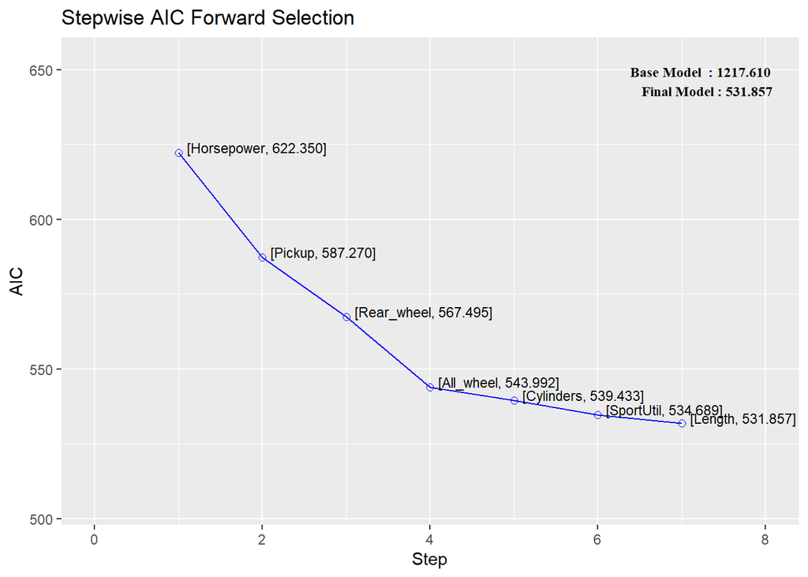

```r
k1 <- ols_step_forward_aic(model)
plot(k1)
```